# Fuel watch analysis

Author

Rebeccah

Western Australia’s population is heavily concentrated in the Perth metro region, with far fewer residents and fuel outlets across the vast northern and interior regions. This concentration explains why the metro region dominates our observations and exhibits strong price competition, while remote regions record fewer entries and often higher average prices due to distance and lower retailer density.

```
Rows: 251,054
Columns: 13
$ PUBLISH_DATE        <chr> "01/01/2025", "01/01/2025", "01/01/2025", "01/01/2…
$ TRADING_NAME        <chr> "53 Mile Roadhouse", "7-Eleven Alkimos", "7-Eleven…
$ BRAND               <chr> "United", "7-Eleven", "7-Eleven", "7-Eleven", "7-E…
$ PRODUCT_DESCRIPTION <chr> "ULP", "ULP", "ULP", "ULP", "ULP", "ULP", "ULP", "…
$ PRICE               <dbl> 175.9, 161.9, 209.9, 209.9, 209.9, 209.9, 209.9, 2…
$ ADDRESS             <chr> "31 South Western Hwy", "10 Carlsbad Prom", "194 G…
$ LOCATION            <chr> "PINJARRA", "ALKIMOS", "ASCOT", "BALCATTA", "BALDI…
$ POSTCODE            <dbl> 6208, 6038, 6104, 6021, 6171, 6061, 6031, 6054, 61…
$ AREA                <chr> "Murray", "North of River", "South of River", "Nor…
$ REGION              <chr> "Peel", "Metro", "Metro", "Metro", "Metro", "Metro…
$ DATE_TIME           <dttm> 2025-01-01 08:00:00, 2025-01-01 08:00:00, 2025-01…
$ DATE                <date> 2025-01-01, 2025-01-01, 2025-01-01, 2025-01-01, 2…
$ WEEKDAY             <ord> Wed, Wed, Wed, Wed, Wed, Wed, Wed, Wed, Wed, Wed, …
```

Western Australia has a very uneven population distribution. The majority of the state’s population lives in the Perth metropolitan area, while most regional and remote areas have far fewer residents spread across large distances. This means there are fewer fuel stations in remote regions, and transport costs to supply them are higher. These structural differences help explain why fuel prices and price variation differ across regions.

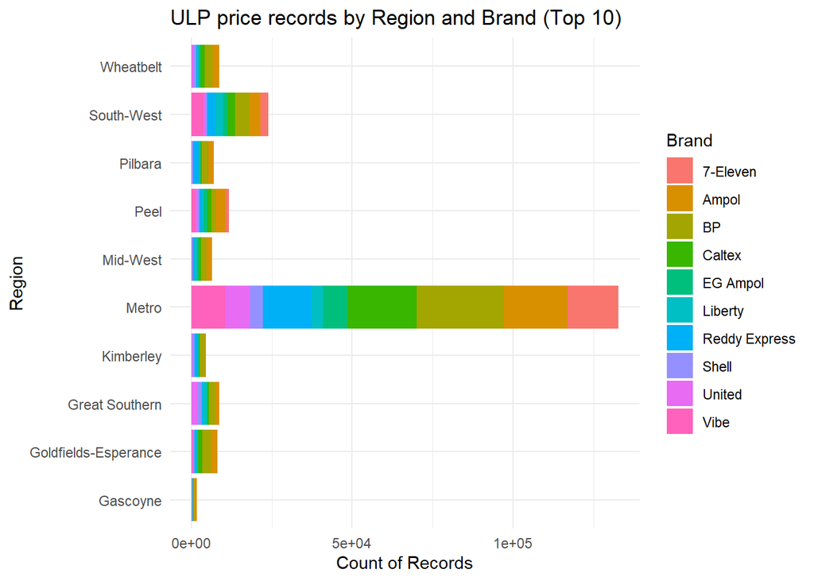

```
# A tibble: 10 × 2
   REGION                    n
   <chr>                 <int>
 1 Metro                152228
 2 South-West            31060
 3 Peel                  12829
 4 Wheatbelt             11137
 5 Great Southern        10320
 6 Mid-West               9197
 7 Goldfields-Esperance   8705
 8 Pilbara                7253
 9 Kimberley              5549
10 Gascoyne               2776
```

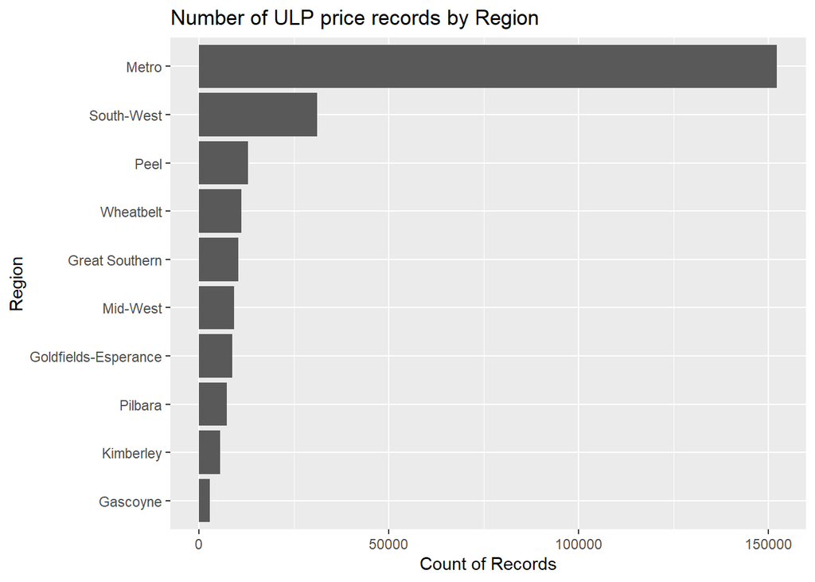

The Metro region has the highest number of ULP price records, significantly more than all other regions. This reflects the high population density and the large number of service stations located in Perth. The South-West region has the next highest number of records, followed by Peel and Wheatbelt. More remote regions such as Pilbara, Kimberley and Gascoyne show far fewer price records, which is consistent with their smaller populations and lower number of fuel outlets. Overall, the dataset shows that most fuel price activity and competition occurs in the Metro area.

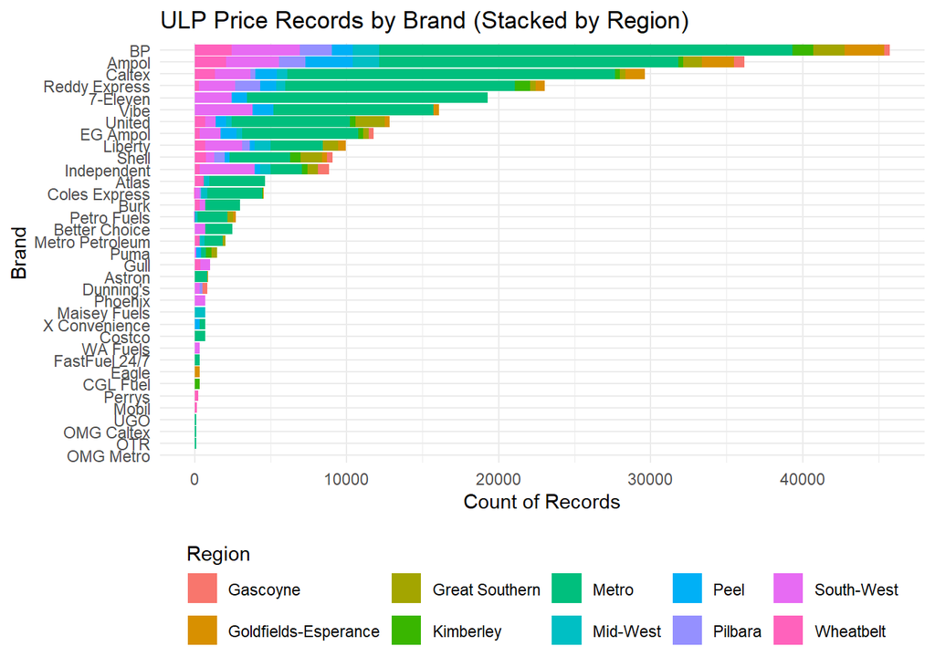

The largest brands in terms of ULP price observations are BP, Ampol, and Caltex, reflecting their strong presence in Western Australia. For most brands, the majority of price records come from the Metro region, which aligns with Perth’s population concentration and higher density of service stations. However, many brands also have stations across multiple regional areas, suggesting that competition is not limited to the metropolitan area. Overall, the stacked bars indicate that while Metro dominates fuel activity, several major brands maintain a statewide footprint.

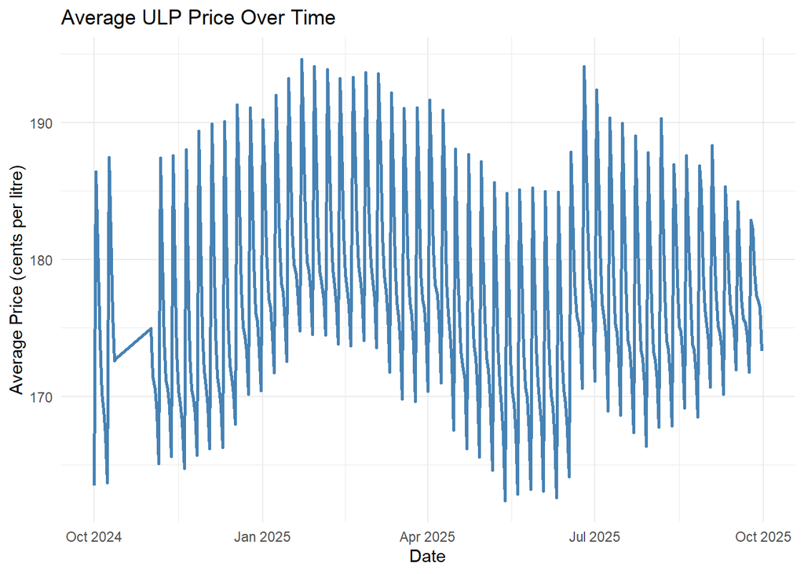

The line chart shows how the average ULP price has changed over time. The trend appears to move in cycles, which is consistent with known fuel price behaviours in Western Australia, where prices typically follow a weekly or fortnightly cycle. Periods of price peaks likely reflect market competition and price resetting by major fuel retailers. Short-term fluctuations may also be influenced by changes in wholesale fuel prices, taxes, or regional competition dynamics.

```
# A tibble: 10 × 2
   REGION               avg_price
   <chr>                    <dbl>
 1 Kimberley                 222.
 2 Gascoyne                  206.
 3 Goldfields-Esperance      192.
 4 Pilbara                   189.
 5 Mid-West                  182.
 6 Wheatbelt                 179.
 7 Great Southern            176.
 8 South-West                176.
 9 Peel                      175.
10 Metro                     174.
```

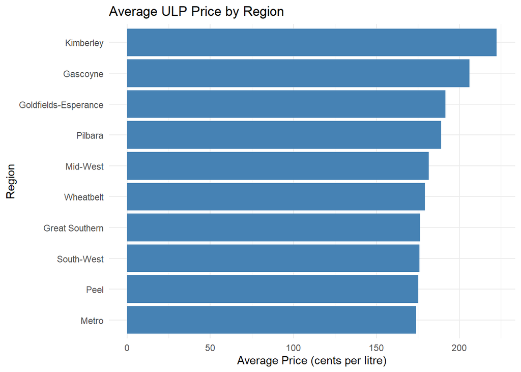

This chart shows the average ULP fuel price for each region. Regional areas such as Kimberley, Pilbara, and Goldfields-Esperance tend to have higher prices compared to the Metro and South-West regions. This is likely due to transportation distances, lower competition, and increased supply costs in remote locations.

Overall, fuel prices tend to increase as distance from major population centers (such as Perth) increases, indicating that geographic location plays a significant role in determining fuel cost.

```
# A tibble: 7 × 2
  WEEKDAY avg_price
  <ord>       <dbl>
1 Mon          172.
2 Tue          169.
3 Wed          189.
4 Thu          184.
5 Fri          178.
6 Sat          175.
7 Sun          174.
```

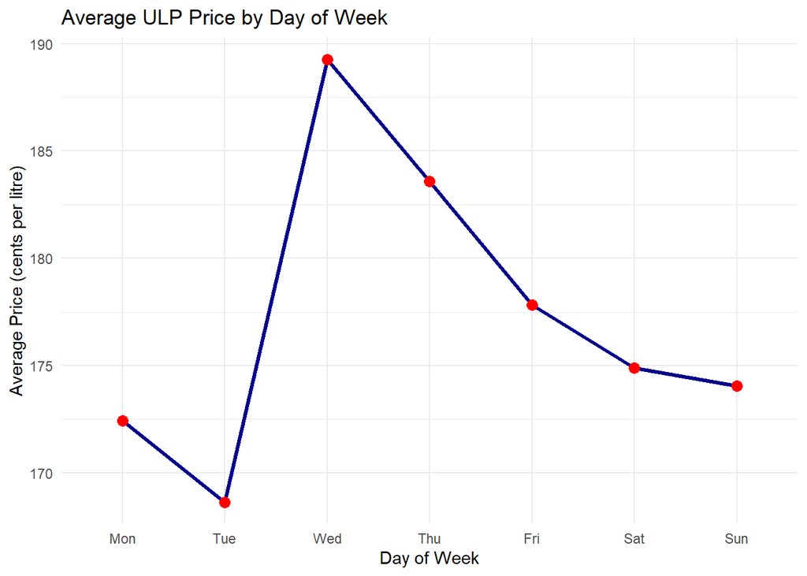

This plot shows how average ULP fuel prices vary across the days of the week.

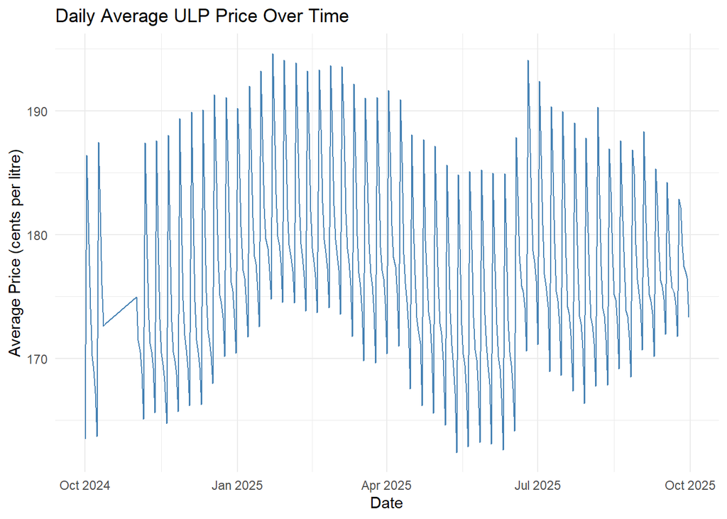

This line chart shows how the average ULP fuel price changes over time. We can see that prices fluctuate rather than remaining constant. These rises and falls may be influenced by factors such as changes in global crude oil prices, refinery output, shipping and supply disruptions, and competitive behaviour between service stations.

If the trend gradually moves upward, it suggests that fuel prices have generally increased over the period studied. Short-term spikes or drops may reflect temporary market shocks or promotional pricing. Overall, this trend helps highlight whether prices are stable, increasing, or volatile across the months.

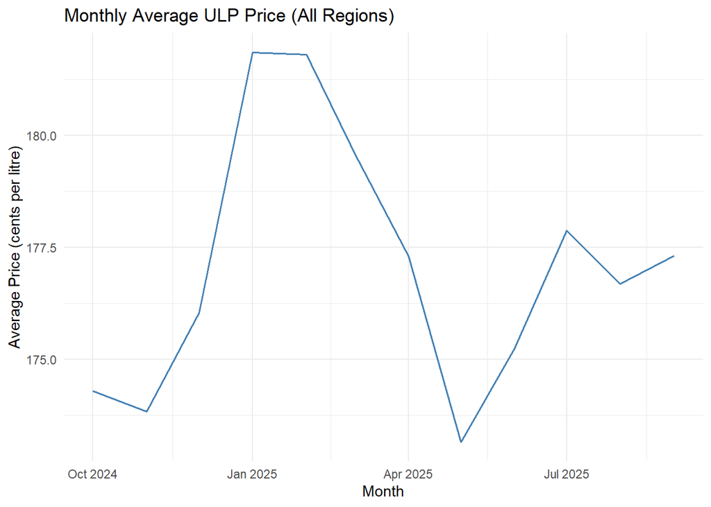

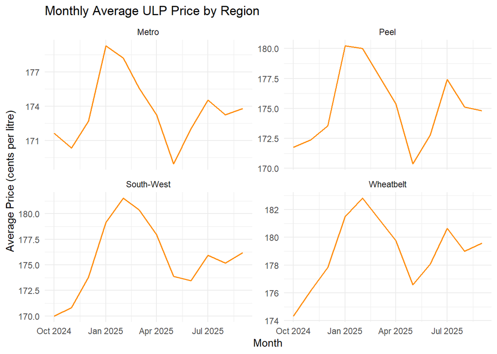

These charts show how average ULP prices evolve month-to-month. Prices do not remain flat; they drift up and down over the year, reflecting movements in crude oil benchmarks, exchange rates, distribution costs, and local retail competition.

The all-regions view provides the headline movement, while the faceted view shows that Metro tends to mirror the state trend closely (consistent with higher competition and frequent price updates). Regional areas (e.g., South-West, Peel, Wheatbelt) follow similar patterns but can show slightly smoother or lagged changes due to fewer stations and less frequent updates. Together, these confirm that month-to-month variation is normal and largely driven by broader market forces.

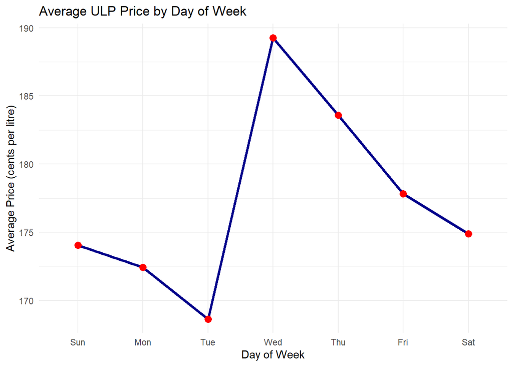

This chart shows how average ULP fuel prices vary across the days of the week.

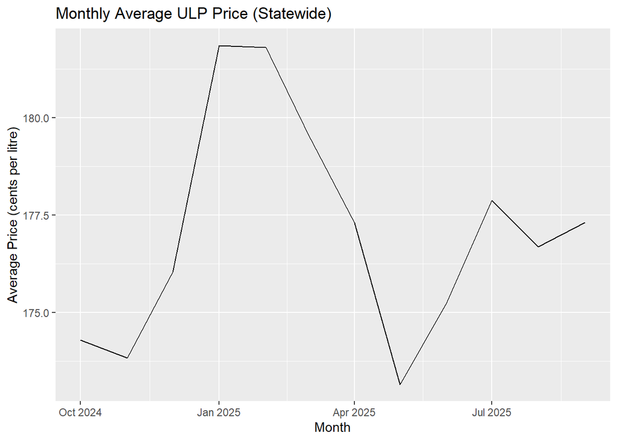

This chart shows how average ULP fuel prices change from month to month. Prices do not stay constant; they move up and down over the year. These fluctuations can be influenced by global oil prices, currency exchange rates, seasonal demand, supply chain costs, and competitive behaviour among fuel retailers.

We can see that some months experience noticeable peaks, while others show dips. This is normal as fuel prices respond quickly to external market conditions. Overall, the chart helps to reveal whether prices are trending upward, downward, or remaining relatively stable over the observed period.

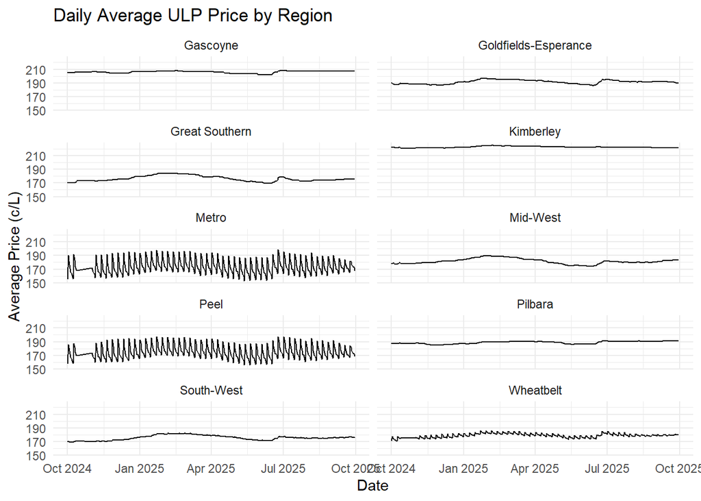

```
# A tibble: 6 × 5
  TRADING_NAME      N_OBS_TRADING_NAME MEAN_PRICE SD_PRICE REGION
  <chr>                          <int>      <dbl>    <dbl> <chr>
1 53 Mile Roadhouse                347       176.     4.73 Peel
2 7-Eleven Alkimos                 347       163.     5.07 Metro
3 7-Eleven Ascot                   347       171.    11.5  Metro
4 7-Eleven Balcatta                347       176.    15.9  Metro
5 7-Eleven Baldivis                347       177.    15.5  Metro
6 7-Eleven Balga                   347       177.    15.9  Metro
```

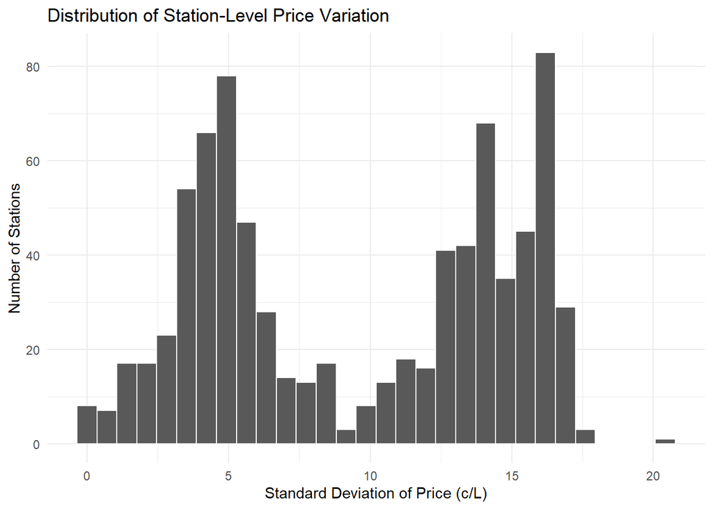

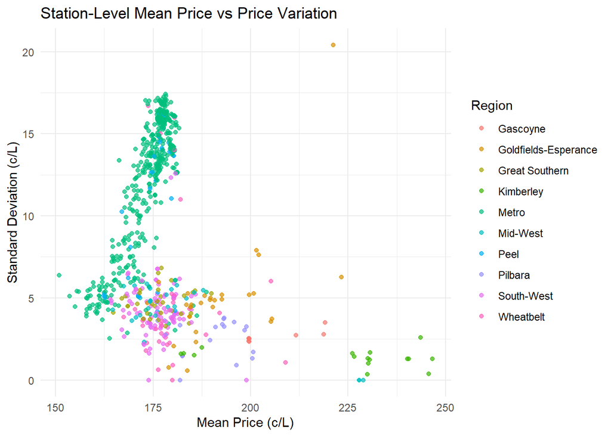

```
# A tibble: 6 × 6
  TRADING_NAME      BRAND    N_OBS_TRADING_NAME MEAN_PRICE SD_PRICE REGION
  <chr>             <chr>                 <int>      <dbl>    <dbl> <chr>
1 53 Mile Roadhouse United                  347       176.     4.73 Peel
2 7-Eleven Alkimos  7-Eleven                347       163.     5.07 Metro
3 7-Eleven Ascot    7-Eleven                347       171.    11.5  Metro
4 7-Eleven Balcatta 7-Eleven                347       176.    15.9  Metro
5 7-Eleven Baldivis 7-Eleven                347       177.    15.5  Metro
6 7-Eleven Balga    7-Eleven                347       177.    15.9  Metro
```

We now examine whether stations can be grouped into clusters based on how their prices change over time. This helps identify common pricing strategies and differences in competition intensity.

We keep only stations that report prices for most of the year, ensuring that clusters are based on comparable time series rather than missing data patterns.

We convert the data into a matrix where each row is a station and each column is a date. This format allows us to apply k-means clustering to compare price patterns directly.

We choose k = 3 clusters, which balances interpretability and variation in pricing behavior across stations.

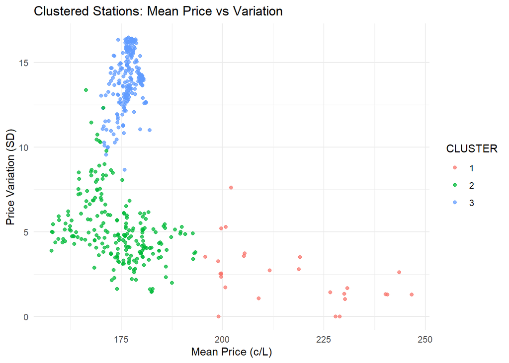

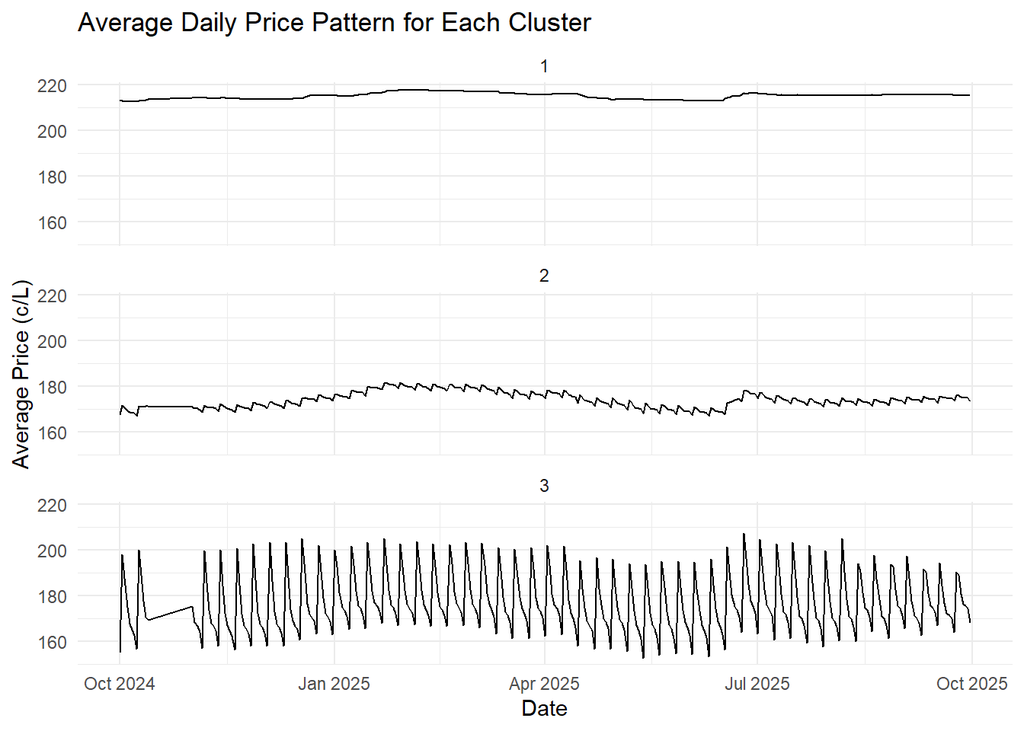

```
# A tibble: 20 × 3
   REGION               CLUSTER     n
   <chr>                <fct>   <int>
 1 Gascoyne             1           7
 2 Goldfields-Esperance 1           5
 3 Goldfields-Esperance 2          12
 4 Great Southern       2          22
 5 Kimberley            1           8
 6 Kimberley            2           3
 7 Metro                2          77
 8 Metro                3         221
 9 Mid-West             1           2
10 Mid-West             2          17
11 Peel                 2           6
12 Peel                 3          21
13 Pilbara              1           3
14 Pilbara              2           9
15 South-West           1           1
16 South-West           2          61
17 South-West           3           1
18 Wheatbelt            1           1
19 Wheatbelt            2          16
20 Wheatbelt            3           3
```

```
# A tibble: 37 × 3
   BRAND    CLUSTER     n
   <chr>    <fct>   <int>
 1 7-Eleven 2          12
 2 7-Eleven 3          41
 3 Ampol    1           5
 4 Ampol    2          35
 5 Ampol    3          59
 6 Astron   2           2
 7 Atlas    2           9
 8 BP       1          10
 9 BP       2          52
10 BP       3          60
# ℹ 27 more rows
```

The region and brand cluster distributions confirm that competition (metro vs remote) and brand pricing strategy both contribute to the observed clustering patterns.

## 2 Conclusion

Overall, fuel prices in Western Australia reflect geography and competition more than random noise. The Metro region records the most observations and exhibits clear weekly price cycles with lower average levels, consistent with dense station competition. Remote regions (e.g., Pilbara, Kimberley, Goldfields–Esperance) show higher average prices and smoother or less regular cycles, pointing to longer supply chains and fewer competitors.

For consumers, buying early in the week (especially Monday–Tuesday) and in highly competitive areas tends to be cheapest. For policymakers and operators, the results suggest that logistics costs and market structure (station density, brand presence) drive persistent regional differences and the strength of the weekly cycle.